# STAT 184 Final Project

```r
# clean up the RStudio environment
rm(list = ls())

# load all packages
library(mosaic)
library(tidyverse)
library(lubridate)
library(DataComputing)
```

# Research Question: Do specific countries perform better than others in Track and Field sprinting events at the Olympic Games?

### Load Primary Data Source into RNotebook

```r
#Primary Data Source
olympicAthleteData <- read.csv(file.choose())
glimpse(olympicAthleteData)
```

```
Observations: 271,116
Variables: 15
$ ID     <int> 1, 2, 3, 4, 5, 5, 5, 5, 5, 5, 6, 6, 6, 6, 6, 6, 6, 6, 7, 7, 7, 7, 7, 7, 7, 7, …
$ Name   <fct> A Dijiang, A Lamusi, Gunnar Nielsen Aaby, Edgar Lindenau Aabye, Christine Jaco…
$ Sex    <fct> M, M, M, M, F, F, F, F, F, F, M, M, M, M, M, M, M, M, M, M, M, M, M, M, M, M, …
$ Age    <int> 24, 23, 24, 34, 21, 21, 25, 25, 27, 27, 31, 31, 31, 31, 33, 33, 33, 33, 31, 31…
$ Height <int> 180, 170, NA, NA, 185, 185, 185, 185, 185, 185, 188, 188, 188, 188, 188, 188, …
$ Weight <dbl> 80.0, 60.0, NA, NA, 82.0, 82.0, 82.0, 82.0, 82.0, 82.0, 75.0, 75.0, 75.0, 75.0…
$ Team   <fct> China, China, Denmark, Denmark/Sweden, Netherlands, Netherlands, Netherlands, …
$ NOC    <fct> CHN, CHN, DEN, DEN, NED, NED, NED, NED, NED, NED, USA, USA, USA, USA, USA, USA…
$ Games  <fct> 1992 Summer, 2012 Summer, 1920 Summer, 1900 Summer, 1988 Winter, 1988 Winter, …
$ Year   <int> 1992, 2012, 1920, 1900, 1988, 1988, 1992, 1992, 1994, 1994, 1992, 1992, 1992, …
$ Season <fct> Summer, Summer, Summer, Summer, Winter, Winter, Winter, Winter, Winter, Winter…
$ City   <fct> Barcelona, London, Antwerpen, Paris, Calgary, Calgary, Albertville, Albertvill…
$ Sport  <fct> Basketball, Judo, Football, Tug-Of-War, Speed Skating, Speed Skating, Speed Sk…
$ Event  <fct> "Basketball Men's Basketball", "Judo Men's Extra-Lightweight", "Football Men's…
$ Medal  <fct> NA, NA, NA, Gold, NA, NA, NA, NA, NA, NA, NA, NA, NA, NA, NA, NA, NA, NA, NA, …
```

### Load Secondary Data Source into RNotebook

```r
library(rvest)
page <- "https://en.wikipedia.org/wiki/List_of_Olympic_records_in_athletics"
tableList <- page %>%
  read_html() %>%
  html_nodes(css = "table") %>%
  html_table(fill = TRUE)

glimpse(tableList[[1]])
```

```
Observations: 25
Variables: 7
$ Event        <chr> "100 metres", "200 metres", "400 metres", "800 metres", "1,500 metres", …
$ Record       <chr> "9.63", "19.30", "♦43.03", "♦1:40.91", "3:32.07", "12:57.82", "27:01.17"…
$ `Athlete(s)` <chr> "Usain Bolt", "Usain Bolt", "Wayde van Niekerk", "David Rudisha", "Noah …
$ Nation       <chr> "Jamaica (JAM)", "Jamaica (JAM)", "South Africa (RSA)", "Kenya (KEN)", "…
$ Games        <chr> "2012 London", "2008 Beijing", "2016 Rio de Janeiro", "2012 London", "20…
$ Date         <chr> "August 5, 2012", "August 20, 2008", "August 14, 2016", "August 9, 2012"…
$ `Ref(s)`     <chr> "[9]", "[10]", "[11]", "[12]", "[13]", "[14]", "[15]", "[16]", "[17]", "…
```

```r
glimpse(tableList[[2]])
```

```
Observations: 23
Variables: 7
$ Event        <chr> "100 metres", "200 metres", "400 metres", "800 metres", "1500 metres", "…
$ Record       <chr> "10.62", "♦21.34", "48.25", "1:53.43", "3:53.96", "14:26.17", "♦29:17.45…
$ `Athlete(s)` <chr> "Florence Griffith Joyner", "Florence Griffith Joyner", "Marie-José Pére…
$ Nation       <chr> "United States (USA)", "United States (USA)", "France (FRA)", "Soviet Un…
$ Games        <chr> "1988 Seoul", "1988 Seoul", "1996 Atlanta", "1980 Moscow", "1988 Seoul",…
$ Date         <chr> "September 24, 1988", "September 29, 1988", "July 29, 1996", "July 27, 1…
$ `Ref(s)`     <chr> "[34]", "[35][36]", "[37]", "[37]", "[37]", "[38]", "[39]", "[37]", "[40…
```

These lists are from Wikipedia and they are a list of both the male and female current olympic records in the track and field events. Each case represents a different event and then has the current record and the athlete who currently hold that record. The tablelist 1 is the male records and the tablelist 2 is the female records.

# Data Wrangling

### Regular Expression of Olympic Records table

```r
#label appropriate tables
malerecords<- tableList[[1]]
femalerecords<- tableList[[2]]
#filter male records
malerecords <-
  malerecords %>%
    filter(grepl(pattern = "\\d*metres$", Event)) %>%
    mutate(Record = ms(Record)) %>%
    mutate(Sex = "M")
malerecords
```

| Event | Record | Athlete(s) | Nation | Games | Date | Ref(s) | Sex |
| --- | --- | --- | --- | --- | --- | --- | --- |
| 100 metres | 9M 63S | Usain Bolt | Jamaica (JAM) | 2012 London | August 5, 2012 | [9] | M |
| 200 metres | 19M 30S | Usain Bolt | Jamaica (JAM) | 2008 Beijing | August 20, 2008 | [10] | M |
| 400 metres | 43M 3S | Wayde van Niekerk | South Africa (RSA) | 2016 Rio de Janeiro | August 14, 2016 | [11] | M |
| 800 metres | 1M 40.91S | David Rudisha | Kenya (KEN) | 2012 London | August 9, 2012 | [12] | M |
| 1,500 metres | 3M 32.07S | Noah Ngeny | Kenya (KEN) | 2000 Sydney | September 29, 2000 | [13] | M |
| 5,000 metres | 12M 57.82S | Kenenisa Bekele | Ethiopia (ETH) | 2008 Beijing | August 23, 2008 | [14] | M |
| 10,000 metres | 27M 1.17S | Kenenisa Bekele | Ethiopia (ETH) | 2008 Beijing | August 17, 2008 | [15] | M |

```r
#filter female records
femalerecords <-
  femalerecords %>%
    filter(grepl(pattern = "\\d*metres$", Event)) %>%
    mutate(Record = ms(Record)) %>%
    mutate(Sex = "F")
femalerecords
```

| Event | Record | Athlete(s) | Nation | Games | Date | Ref(s) | Sex |
| --- | --- | --- | --- | --- | --- | --- | --- |
| 100 metres | 10M 62S | Florence Griffith Joyner | United States (USA) | 1988 Seoul | September 24, 1988 | [34] | F |
| 200 metres | 21M 34S | Florence Griffith Joyner | United States (USA) | 1988 Seoul | September 29, 1988 | [35][36] | F |
| 400 metres | 48M 25S | Marie-José Pérec | France (FRA) | 1996 Atlanta | July 29, 1996 | [37] | F |
| 800 metres | 1M 53.43S | Nadezhda Olizarenko | Soviet Union (URS) | 1980 Moscow | July 27, 1980 | [37] | F |
| 1500 metres | 3M 53.96S | Paula Ivan | Romania (ROU) | 1988 Seoul | September 26, 1988 | [37] | F |
| 5,000 metres | 14M 26.17S | Vivian Cheruiyot | Kenya (KEN) | 2016 Rio de Janeiro | August 19, 2016 | [38] | F |
| 10,000 metres | 29M 17.45S | Almaz Ayana | Ethiopia (ETH) | 2016 Rio de Janeiro | August 12, 2016 | [39] | F |

This was done to filter both the male and female records to only keep the records that have metres in that specific event. This made it easier to convert the times into something that we could use for the research question.

### Joining Two Data Tables

```r
#join sprinting records
SprintingRecords <-
  malerecords %>%
    full_join(femalerecords)
```

```
Column `Record` has different attributes on LHS and RHS of join
```

```r
SprintingRecords
```

| Event | Record | Athlete(s) | Nation | Games | Date | Ref(s) | Sex |
| --- | --- | --- | --- | --- | --- | --- | --- |
| 100 metres | 9M 63S | Usain Bolt | Jamaica (JAM) | 2012 London | August 5, 2012 | [9] | M |
| 200 metres | 19M 30S | Usain Bolt | Jamaica (JAM) | 2008 Beijing | August 20, 2008 | [10] | M |
| 400 metres | 43M 3S | Wayde van Niekerk | South Africa (RSA) | 2016 Rio de Janeiro | August 14, 2016 | [11] | M |
| 800 metres | 1M 40.91S | David Rudisha | Kenya (KEN) | 2012 London | August 9, 2012 | [12] | M |
| 1,500 metres | 3M 32.07S | Noah Ngeny | Kenya (KEN) | 2000 Sydney | September 29, 2000 | [13] | M |
| 5,000 metres | 12M 57.82S | Kenenisa Bekele | Ethiopia (ETH) | 2008 Beijing | August 23, 2008 | [14] | M |
| 10,000 metres | 27M 1.17S | Kenenisa Bekele | Ethiopia (ETH) | 2008 Beijing | August 17, 2008 | [15] | M |
| 100 metres | 62S | Florence Griffith Joyner | United States (USA) | 1988 Seoul | September 24, 1988 | [34] | F |
| 200 metres | 34S | Florence Griffith Joyner | United States (USA) | 1988 Seoul | September 29, 1988 | [35][36] | F |
| 400 metres | 25S | Marie-José Pérec | France (FRA) | 1996 Atlanta | July 29, 1996 | [37] | F |

[output cut: 4 more lines]

Joined the male and female sprinting records into one table.

### Using Data Verbs on primary data set

```r
#fitting the data to match our needs for the research question
olympicAthleteData <-
  olympicAthleteData%>%
  select(Name, Sex, Age, Team, Year, Sport, Event, Medal)%>%
  filter(Sport == "Athletics") %>%
  mutate(Name = as.character(Name),
         Sex = as.character(Sex),
         Sport = as.character(Sport),
         Event = as.character(Event),
         Medal = as.character(Medal),
         Team = as.character(Team)) %>%
  filter(grepl(pattern = "\\d*metres$", Event)) %>%
  mutate(Event = (gsub(pattern = "Athletics Women's|Athletics Men's", replacement = "", Event))) %>%
  rename("Athlete(s)" = Name) %>%
  rename("Nation" = Team)

olympicAthleteData
```

| Athlete(s) | Sex | Age | Nation | Year | Sport | Event | Medal |
| --- | --- | --- | --- | --- | --- | --- | --- |
| Cornelia "Cor" Aalten (-Strannood) | F | 18 | Netherlands | 1932 | Athletics | 100 metres | NA |
| Jamale (Djamel-) Aarrass (Ahrass-) | M | 30 | France | 2012 | Athletics | 1,500 metres | NA |
| Antonio Abadia Beci | M | 26 | Spain | 2016 | Athletics | 5,000 metres | NA |
| Jos Manuel Abascal Gmez | M | 22 | Spain | 1980 | Athletics | 1,500 metres | NA |
| Jos Manuel Abascal Gmez | M | 26 | Spain | 1984 | Athletics | 1,500 metres | Bronze |
| Carlos Rodolfo Abaunza Balladares | M | 18 | Nicaragua | 2004 | Athletics | 100 metres | NA |
| Gana Abba Kimet | M | 26 | Chad | 1972 | Athletics | 100 metres | NA |
| Abubakar Abbas Abbas | M | 20 | Bahrain | 2016 | Athletics | 400 metres | NA |
| Maher Abbas | M | 22 | Lebanon | 1988 | Athletics | 400 metres | NA |
| Maher Abbas | M | 22 | Lebanon | 1988 | Athletics | 800 metres | NA |

[output cut: 990 more lines]

Since our research question is looking at if countries perform better than others in Track and Field at the olympics, we didn’t need all of the information that the data table provided. For example, we only kept the athletes whose sport was “Athletics”, which was the label for Track and Field in the data set that we found. We kept filtering out unnecessary data until we were left with only the athletes that competed in the events that we had records for.

### Using Data verbs on secondary data set

```r
#fitting the records data table to match the olympic data table
SprintingRecords <-
  SprintingRecords %>%
  select(Event, Record, Nation, Date, `Athlete(s)`, Sex) %>%
  mutate(Date = mdy(Date),
         Year = year(Date)) %>%
  select(Event, Record, Nation, Year, `Athlete(s)`, Sex) %>%
  mutate(Nation = (gsub(pattern = "\\(.{3}\\)$", replacement = "", Nation))) %>%
  mutate(Medal = "Gold")

SprintingRecords
```

| Event | Record | Nation | Year | Athlete(s) | Sex | Medal |
| --- | --- | --- | --- | --- | --- | --- |
| 100 metres | 9M 63S | Jamaica | 2012 | Usain Bolt | M | Gold |
| 200 metres | 19M 30S | Jamaica | 2008 | Usain Bolt | M | Gold |
| 400 metres | 43M 3S | South Africa | 2016 | Wayde van Niekerk | M | Gold |
| 800 metres | 1M 40.91S | Kenya | 2012 | David Rudisha | M | Gold |
| 1,500 metres | 3M 32.07S | Kenya | 2000 | Noah Ngeny | M | Gold |
| 5,000 metres | 12M 57.82S | Ethiopia | 2008 | Kenenisa Bekele | M | Gold |
| 10,000 metres | 27M 1.17S | Ethiopia | 2008 | Kenenisa Bekele | M | Gold |
| 100 metres | 62S | United States | 1988 | Florence Griffith Joyner | F | Gold |
| 200 metres | 34S | United States | 1988 | Florence Griffith Joyner | F | Gold |
| 400 metres | 25S | France | 1996 | Marie-José Pérec | F | Gold |

[output cut: 4 more lines]

### Fix names in secondary data set to match with primary data set

```r
#fitting the records data table to match the olympic data table
SprintingRecords <-
SprintingRecords %>%
  mutate(`Athlete(s)` = gsub(pattern = "Usain Bolt", replacement = "Usain St. Leo Bolt", `Athlete(s)`)) %>%
  mutate(`Athlete(s)` = gsub(pattern = "David Rudisha", replacement = "David Lekuta Rudisha", `Athlete(s)`)) %>%
  mutate(`Athlete(s)` = gsub(pattern = "Noah Ngeny", replacement = "Noah Kiprono Ngeny", `Athlete(s)`)) %>%
  mutate(`Athlete(s)` = gsub(pattern = "Kenenisa Bekele", replacement = "Kenenisa Bekele Beyecha", `Athlete(s)`)) %>%
  mutate(`Athlete(s)` = gsub(pattern = "Florence Griffith Joyner", replacement = "Delorez Florence Griffith Joyner", `Athlete(s)`)) %>%
  mutate(`Athlete(s)` = gsub(pattern = "Marie-José Pérec", replacement = "Marie Jos- Juliana Prec \\(Hontas-\\)", `Athlete(s)`)) %>%
  mutate(`Athlete(s)` = gsub(pattern = "Nadezhda Olizarenko", replacement = "Nadiya Fedorivna Olizarenko \\(Mushta-\\)", `Athlete(s)`)) %>%
  mutate(`Athlete(s)` = gsub(pattern = "Paula Ivan", replacement = "Paula Ivan \\(Ilie\\)", `Athlete(s)`)) %>%
  mutate(`Athlete(s)` = gsub(pattern = "Vivian Cheruiyot", replacement = "Vivian Jepkemoi Cheruiyot", `Athlete(s)`)) %>%
  mutate(`Athlete(s)` = gsub(pattern = "Almaz Ayana", replacement = "Almaz Ayana Eba", `Athlete(s)`))

SprintingRecords
```

| Event | Record | Nation | Year | Athlete(s) | Sex | Medal |
| --- | --- | --- | --- | --- | --- | --- |
| 100 metres | 9M 63S | Jamaica | 2012 | Usain St. Leo Bolt | M | Gold |
| 200 metres | 19M 30S | Jamaica | 2008 | Usain St. Leo Bolt | M | Gold |
| 400 metres | 43M 3S | South Africa | 2016 | Wayde van Niekerk | M | Gold |
| 800 metres | 1M 40.91S | Kenya | 2012 | David Lekuta Rudisha | M | Gold |
| 1,500 metres | 3M 32.07S | Kenya | 2000 | Noah Kiprono Ngeny | M | Gold |
| 5,000 metres | 12M 57.82S | Ethiopia | 2008 | Kenenisa Bekele Beyecha | M | Gold |
| 10,000 metres | 27M 1.17S | Ethiopia | 2008 | Kenenisa Bekele Beyecha | M | Gold |
| 100 metres | 62S | United States | 1988 | Delorez Florence Griffith Joyner | F | Gold |
| 200 metres | 34S | United States | 1988 | Delorez Florence Griffith Joyner | F | Gold |
| 400 metres | 25S | France | 1996 | Marie Jos- Juliana Prec (Hontas-) | F | Gold |

[output cut: 4 more lines]

For these chunks of code, we wrangled the sprinting records table to match that of the Olympic athletes table. This was done so that we could join the two tables and then from there, wrangle the data a bit more to make it gylph ready.

### Join primary and secondary data set

```r
#join of primary and secondary data sets
completeOlympicData<-
  olympicAthleteData%>%
  full_join(SprintingRecords)%>%
  arrange(Record) %>%
  select(`Athlete(s)`,Sex, Nation, Event, Record, Year, Medal)
completeOlympicData
```

| Athlete(s) | Sex | Nation | Event | Record | Year | Medal |
| --- | --- | --- | --- | --- | --- | --- |
| Kenenisa Bekele Beyecha | M | Ethiopia | 10,000 metres | 27M 1.17S | 2008 | Gold |
| Wayde van Niekerk | M | South Africa | 400 metres | 43M 3S | 2016 | Gold |
| Almaz Ayana Eba | F | Ethiopia | 10,000 metres | 17.45S | 2016 | Gold |
| Marie Jos- Juliana Prec (Hontas-) | F | France | 400 metres | 25S | 1996 | Gold |
| Vivian Jepkemoi Cheruiyot | F | Kenya | 5,000 metres | 26.17S | 2016 | Gold |
| Usain St. Leo Bolt | M | Jamaica | 200 metres | 19M 30S | 2008 | Gold |
| Noah Kiprono Ngeny | M | Kenya | 1,500 metres | 3M 32.07S | 2000 | Gold |
| Delorez Florence Griffith Joyner | F | United States | 200 metres | 34S | 1988 | Gold |
| David Lekuta Rudisha | M | Kenya | 800 metres | 1M 40.91S | 2012 | Gold |
| Nadiya Fedorivna Olizarenko (Mushta-) | F | Soviet Union | 800 metres | 53.43S | 1980 | Gold |

[output cut: 990 more lines]

This was an important data set in the wrangling process because it was the the final data table that would be used for making our glyph-ready data. This table combined the two data sources to create one table with data on the different countries, records, metals, and athletes that we needed to explain the research question.

### Making the data glyph ready

```r
#making glyph ready data
AthleteCounts <-
completeOlympicData %>%
  group_by(Nation, Sex) %>%
  summarise(count = n()) %>%
  spread(key = Sex, value = count) %>%
  mutate(TotalAthletes = F + M) %>%
  arrange(desc(TotalAthletes)) %>%
  na.omit()
AthleteCounts
```

| Nation | F | M | TotalAthletes |
| --- | --- | --- | --- |
| United States | 269 | 696 | 965 |
| Great Britain | 241 | 578 | 819 |
| France | 115 | 363 | 478 |
| Canada | 152 | 302 | 454 |
| Australia | 140 | 206 | 346 |
| Germany | 90 | 229 | 319 |
| Italy | 78 | 203 | 281 |
| Kenya | 80 | 194 | 274 |
| Jamaica | 121 | 141 | 262 |
| Soviet Union | 100 | 134 | 234 |

[output cut: 200 more lines]

```r
MedalCounts <-
  completeOlympicData %>%
    group_by(Nation, Medal) %>%
    summarise(count = n()) %>%
    spread (key = Medal, value = count) %>%
    mutate(TotalMedals = sum(Bronze + Gold + Silver)) %>%
    select(Bronze, Gold, Silver, TotalMedals) %>%
    arrange(desc(TotalMedals)) %>%
    na.omit()
MedalCounts
```

| Nation | Bronze | Gold | Silver | TotalMedals |
| --- | --- | --- | --- | --- |
| United States | 58 | 89 | 78 | 225 |
| Great Britain | 22 | 24 | 28 | 74 |
| Kenya | 19 | 15 | 19 | 53 |
| Jamaica | 15 | 15 | 20 | 50 |
| Ethiopia | 16 | 16 | 8 | 40 |
| Australia | 17 | 10 | 7 | 34 |
| Finland | 8 | 17 | 8 | 33 |
| Soviet Union | 11 | 16 | 5 | 32 |
| East Germany | 12 | 7 | 9 | 28 |
| Germany | 11 | 4 | 11 | 26 |

[output cut: 22 more lines]

```r
Counts <-
  MedalCounts %>%
    left_join(AthleteCounts)
Counts
```

| Nation | Bronze | Gold | Silver | TotalMedals | F | M | TotalAthletes |
| --- | --- | --- | --- | --- | --- | --- | --- |
| United States | 58 | 89 | 78 | 225 | 269 | 696 | 965 |
| Great Britain | 22 | 24 | 28 | 74 | 241 | 578 | 819 |
| Kenya | 19 | 15 | 19 | 53 | 80 | 194 | 274 |
| Jamaica | 15 | 15 | 20 | 50 | 121 | 141 | 262 |
| Ethiopia | 16 | 16 | 8 | 40 | 62 | 118 | 180 |
| Australia | 17 | 10 | 7 | 34 | 140 | 206 | 346 |
| Finland | 8 | 17 | 8 | 33 | 36 | 164 | 200 |
| Soviet Union | 11 | 16 | 5 | 32 | 100 | 134 | 234 |
| East Germany | 12 | 7 | 9 | 28 | 56 | 38 | 94 |
| Germany | 11 | 4 | 11 | 26 | 90 | 229 | 319 |

[output cut: 22 more lines]

With this data table, each of the countries are its own case, with the variables of medal counts for each medal- gold, silver, and bronze, and also the total counts of the total athletes that have competed from each country. With this data we will be able to look at total medal counts by country and see how medal counts compared to the athlete counts for each country.

# Graphics

### Bar Graphs

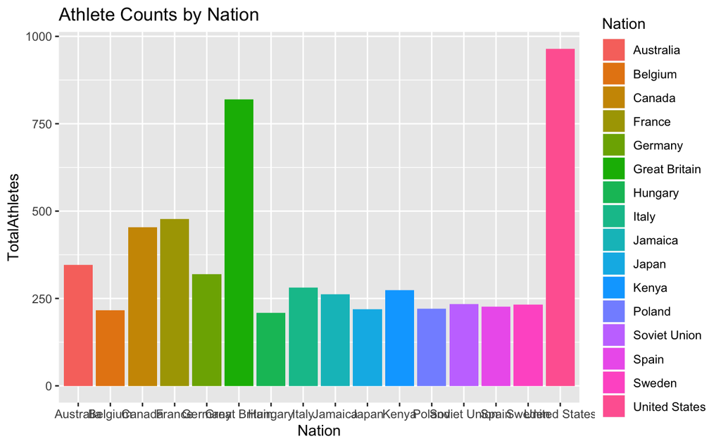

```r
#athlete counts by country
AthleteCounts%>%
  filter(TotalAthletes > 200)%>%
  ggplot(aes(x = Nation, y = TotalAthletes))+
  geom_bar(stat = "identity", aes(fill = Nation))+
  labs(title = "Athlete Counts by Nation")
```

This bar graph makes it clear to see that some countries send a lot more athletes to the Olympics compared to other countries. The United States and Great Britain send hundreds more athletes to the Olympics when compared to countries like Spain or Sweden.

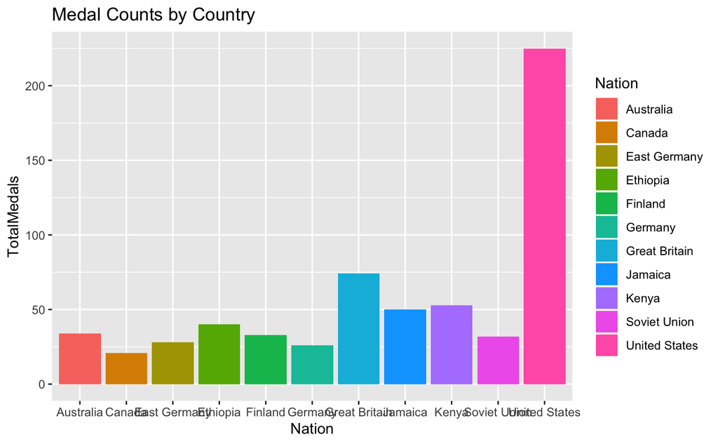

```r
#medal counts by country
MedalCounts%>%
  filter(TotalMedals > 20) %>%
  ggplot(aes(x = Nation, y = TotalMedals)) +
  geom_bar(stat = "identity", aes(fill = Nation)) +
  labs(title = "Medal Counts by Country")
```

This bar graph demonstrates that there are certainly countries that have earned more medals in Track and Field events than others. The United States has clearly earned the most medals, but other countries that have performed well in Track and Field at the Olympics are Great Britain, Kenya, and Jamaica.

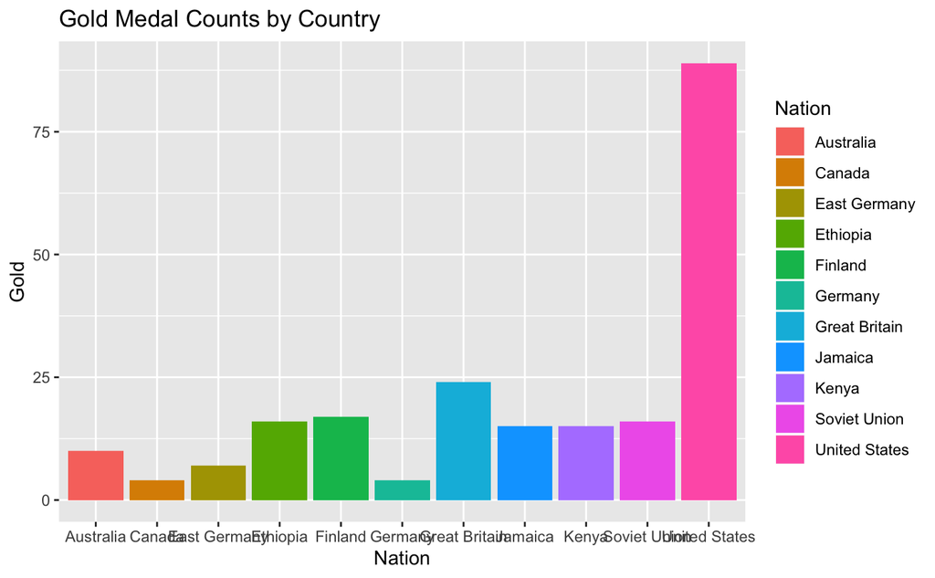

```r
#gold medal counts by country
MedalCounts%>%
  filter(TotalMedals > 20) %>%
  ggplot(aes(x = Nation, y = Gold)) +
  geom_bar(stat = "identity", aes(fill = Nation)) +
  labs(title = "Gold Medal Counts by Country")
```

When we investigate the counts of just the gold medals, the top countries with the highest counts are pretty similar to the countries that earn the highest total counts of medals. The United States and Great Britain still earn the highest two counts.

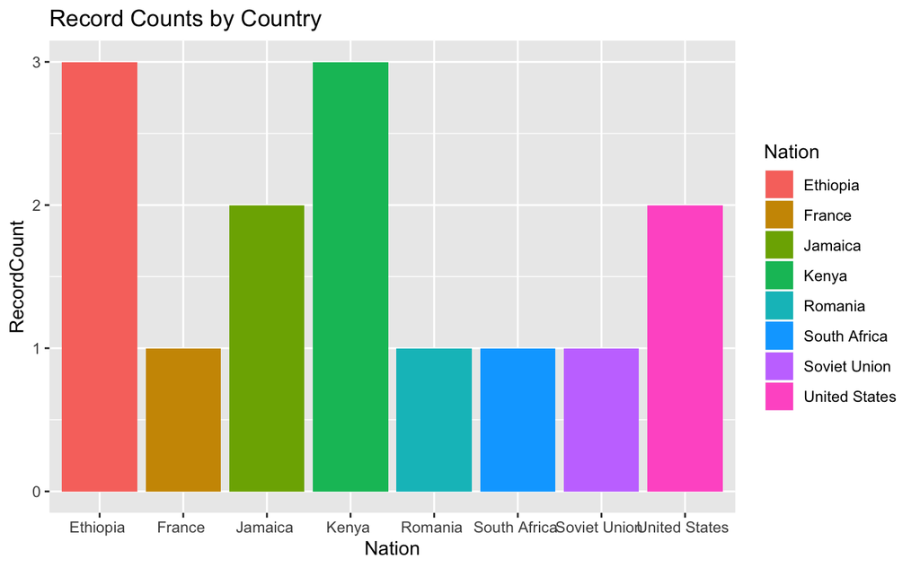

```r
RecordCounts <-
  completeOlympicData %>%
  select(Nation, Event, Record) %>%
  filter(is.na(Record) == FALSE)

RecordCounts %>%
  group_by(Nation) %>%
  summarise(RecordCount= n()) %>%
  ggplot(aes(x = Nation, y = RecordCount)) +
  geom_bar(stat = "identity", aes(fill = Nation)) +
  labs(title = "Record Counts by Country")
```

This graph shows that the countries with greater counts of track and field athletes do not necessarily perform the best in track and field events. Ethiopia and Kenya currently have the most athletes holding records in sprinting events, yet their athlete counts are small in comparison to countries like the United States and Great Britain. The United States also has athletes who hold records in sprinting events, but Great Britain, the nation with the second highest count of sprinting athletes, does not currently hold any records for those events.

### Scatter Plot

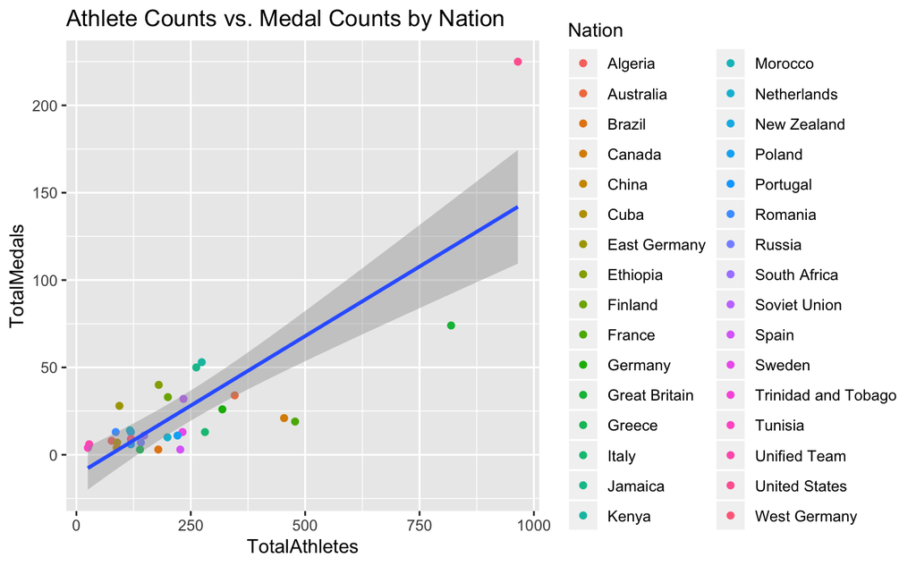

```r
#Metal counts compared to athlete counts by nation
Counts %>%
  ggplot(aes(x = TotalAthletes, y = TotalMedals)) +
  geom_point(aes(color = Nation)) +
  geom_smooth(method = lm) +
  theme(legend.position = "right") +
  labs(title = "Athlete Counts vs. Medal Counts by Nation")
```

This scatterplot demonstrates that countries with more total track and field athletes tend to earn more total medals on those events. However, the linear model has a wide confidence band, so the relationship between total athletes and total medals might not be modelled best by a simple linear relationship. There are most likely other variables that contribute more significantly to the number of medals that a nation earns.

# Conclusion

When observing the different graphics of the data, it is very clear to see that some countries do perform better than others. This can be seen when loking at the graphs that look at the total medal counts by each country. The United States has significantly more medals when compared to other countries, followed by Great Britain and then Kenya. However, there seems to be a relationship between the number of athletes a country sends to the Olympics and the number of medals they earn. For example, the United States has sent more athletes to the Olympics than any other country and they have received the most medals. The same goes for Great Britain, who sent the second-most athletes to the Olympics and received the second-most medals. This can be observed in the athlete count versus metal count scatter plot which has a moderately strong linear trend. This gives the impression that as a country sends more athletes to the Olympics, they will receive more medals as a country. However, this relationship between the number of athletes a country sends to the Olympics doesn’t appear to apply when it comes to the number of records that a country holds. The two countries that are currently tied with the most records are Ethiopia and Kenya, neither of which are in the top 5 countries for number of athletes sent to the Olympics. This proves that the number of athletes is not the only variable that affects the performance of a specific country in track and field events at the Olympics.